# Exploring the BRFSS data

Mahadev Suresh

## Project Summary

This Project is a course requirement for the course INTRODUCTION TO PROBABILITY AND DATA by The Duke University. Exploratory analysis is performed and 3 research questions are answered based on the Behaviourial Risk Factor Surveillance system (BRFSS) conducted by the CDC, the data used in this project is of the year 2013.

## Setup

### Load packages

```r
library(ggplot2)
library(dplyr)
```

### Load data

```r
load("brfss2013.RData")
```

## Part 1: Data

**About the Data**

The BRFSS is an annual telephonic survey conducted in all the 50 states of U.S, Guam,Puerto Rico and the District of Columbia by the Center for Disease control and prevention (CDC).

“The BRFSS objective is to collect uniform, state-specific data on preventive health practices and risk behaviors that are linked to chronic diseases, injuries, and preventable infectious diseases that affect the adult population. Factors assessed by the BRFSS in 2013 include tobacco use, HIV/AIDS knowledge and prevention, exercise, immunization, health status, healthy days - health-related quality of life, health care access, inadequate sleep, hypertension awareness, cholesterol awareness, chronic health conditions, alcohol consumption, fruits and vegetables consumption, arthritis burden, and seatbelt use. Since 2011, BRFSS conducts both landline telephone and cellular telephone-based surveys” as per the CDC website.

The BRFSS data set has 491775 observations and 330 variables including the ones directly collected and computed variables.

**Sampling Methodology**

According to CDC :“BRFSS is a cross-sectional telephone survey that state health departments conduct monthly over landline telephones and cellular telephones with a standardized questionnaire and technical and methodological assistance from CDC. In conducting the BRFSS landline telephone survey, interviewers collect data from a randomly selected adult in a household. In conducting the cellular telephone version of the BRFSS questionnaire, interviewers collect data from an adult who participates by using a cellular telephone and resides in a private residence or college housing”.

A Disprotionte Stratified Sampling (DSS) is employed to collect the data in both of the above cases, i.e telephone and cell phone.

**Generalizability**

The results of the Analysis on the above data set are generalizable to the whole adult population of the U.S as the data is collected by randomly sample a telephone user for the set that includes samples all 50 states.

**Causality**

It is not possible to make causal conclusions form the analysis of the data set as it does not invole Random Assignent.

**Bias**

The survey is lilkely to suffer from many kinds of bias like:

1. Convience Bias: Only people who own a cell or telephone are included in survey thus the survey does not represent the whole population.
2. Under Coverage Bias: Is caused when the lower income strata of the population is not represented, because they might not be able to afford a telephone.
3. Voluntary Response Bias: Since the responders are free to decide whether they should respond or not, thus it might over represent the views of the people with stonge beliefs.
4. The responder might not reveal certain information because s/he considers it as not neccessary.
5. The responder might not remember exact details and hence might no be able to answer the questions accurately.

## Part 2: Research questions

**Research quesion 1:**

How is smoking (atleast 100 cigarettes in any part of life) associated with the quality of the General Health reported ?

Is the above trend same for both the sexes ? Which gender has a stronger trend (if any) ?

**Research quesion 2:**

How does BMI category vary with increase Educational Qualification ? Does the likelihood of person being obese or Underweight reduce with increase in Eduvational qualification ?

What is the trend in BMI Catergory as income varies ? Does the chances of being overweight or under weight besomes with higher income and hence access to better health care facilities ?

**Research quesion 3:**

How does a plot of sleep time look ? On an average people of which gender sleep more ?

What is the association between a person between a person suffering from hypertension and his/her sleep time, it is checked whether the trend is same for both genders ?

What is the association between a person binge drinking alcohol and s/he suffering from hypertension ?

## Part 3: Exploratory data analysis

**Research quesion 1:**

Variables Used:

genhlth : General health. smoke100 : Smoked atlaest 100 cigarettes. sex : Gender.

This is to see how likely a person is to have good health given s/he has smoked atleast 100 cigarettes in lifetime.

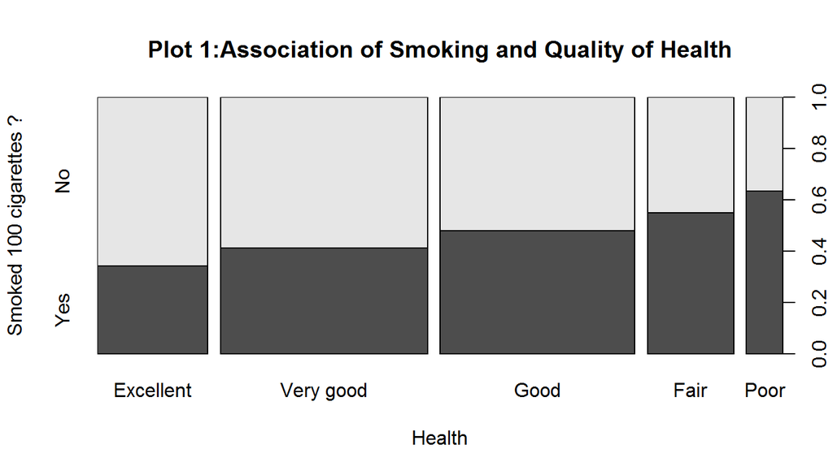

```r
#General Health, Smoked 100 cigr. atleast

plot(brfss2013$genhlth,brfss2013$smoke100,main="Plot 1:Association of Smoking and Quality of Health",xlab="Health",ylab="Smoked 100 cigarettes ?")
```

It can be observed as we move from Excellent health qualilty to Poor the likelihood of the person being a smoker increases drastically.

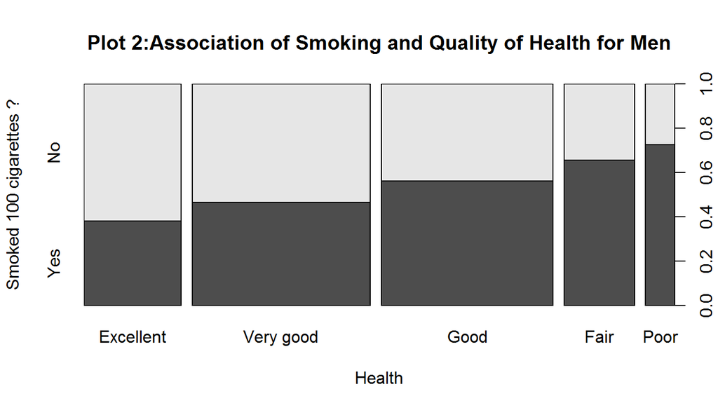

```r
Men<-brfss2013  %>% filter(sex=="Male")

plot(Men$genhlth,Men$smoke100,main="Plot 2:Association of Smoking and Quality of Health for Men",xlab="Health",ylab="Smoked 100 cigarettes ?")
```

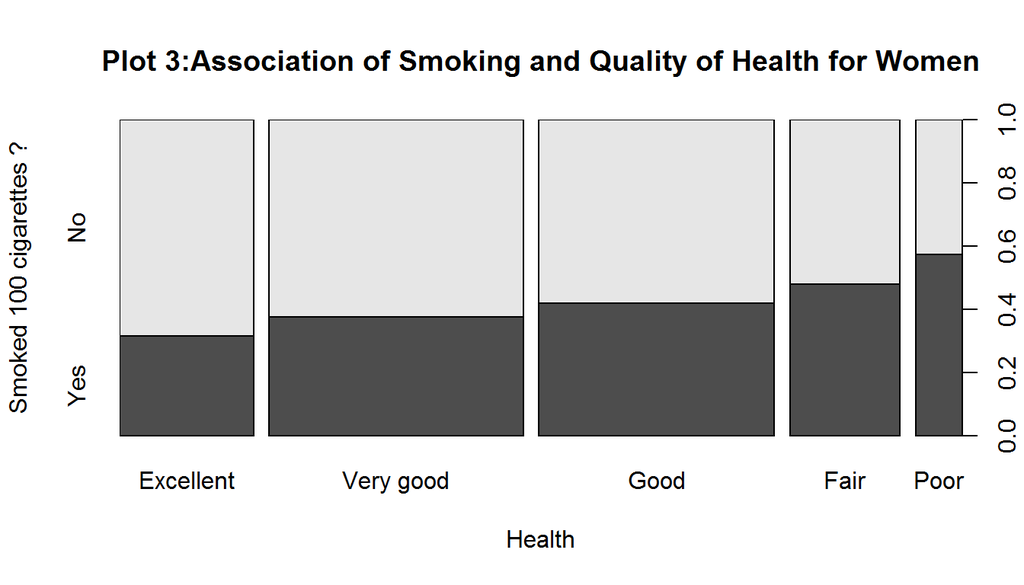

```r
Women<-brfss2013  %>% filter(sex=="Female")

plot(Women$genhlth,Women$smoke100,main="Plot 3:Association of Smoking and Quality of Health for Women",xlab="Health",ylab="Smoked 100 cigarettes ?")
```

Now we verify whether the above trend is the same for different sexes, and the plots 2 and 3 shows that it is so.

```r
#Summary Statistics all adults
prop.table(table(brfss2013$smoke100,brfss2013$genhlth))
```

```
##
##        Excellent  Very good       Good       Fair       Poor
##   Yes 0.05966900 0.13398682 0.14687770 0.07455783 0.03604730
##   No  0.11451261 0.19191473 0.15999385 0.06146484 0.02097531
```

```r
#Summary Statistics (Men)
prop.table(table(Men$smoke100,Men$genhlth))
```

```
##
##        Excellent  Very good       Good       Fair       Poor
##   Yes 0.06755560 0.15108721 0.17598859 0.08448441 0.03867824
##   No  0.11027677 0.17481433 0.13817043 0.04434350 0.01460091
```

```r
#Summary Statistics (Women)
prop.table(table(Women$smoke100,Women$genhlth))
```

```
##
##        Excellent  Very good       Good       Fair       Poor
##   Yes 0.05421603 0.12216323 0.12674978 0.06769437 0.03422821
##   No  0.11744136 0.20373832 0.17508306 0.07330292 0.02538272
```

*Summary Statistics:*

The tables above illustate the trend as probabilities rather than a PLOT, the conclusions that could be drawn are the same as from the plot. That is a person who has smoked atleast 100 ciragettes is very less likely to report a good health.

As an overall conclusion trend is stronger for men when we compare it with the trend observed in women.

**Research quesion 2:**

Variables Used:

X_bmi5cat : The weight category based on BMI comutation. X_educag : The educational qualification. income2 : Income Strata.

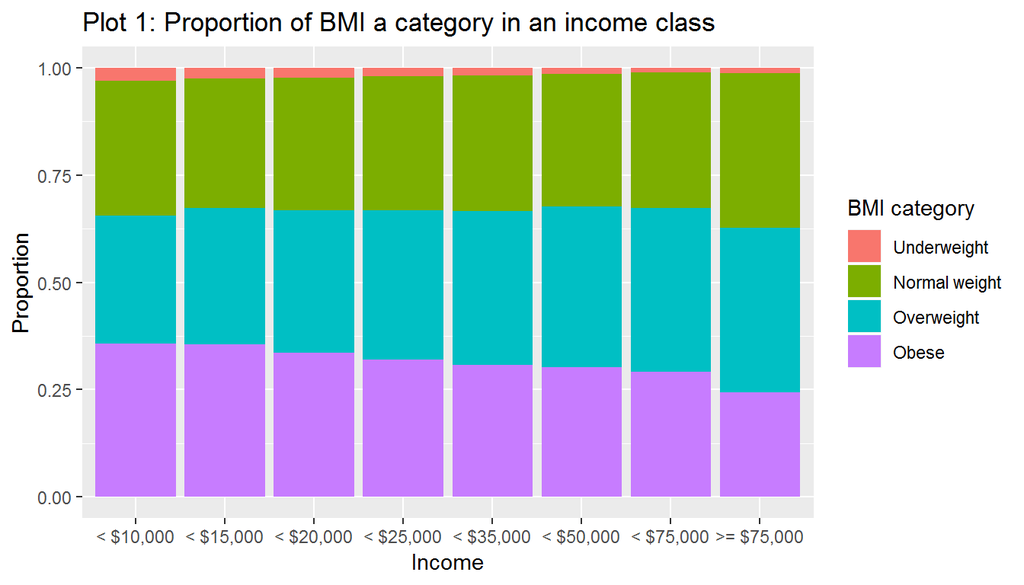

```r
#Variables Computed for plotting
IncomeBMI <- brfss2013[!is.na(brfss2013$X_bmi5cat),]
EduBMI <- IncomeBMI[!is.na(IncomeBMI$X_educag),]
IncomeBMI <- IncomeBMI[!is.na(IncomeBMI$income2),]
EduBMI <- EduBMI[!is.na(EduBMI$X_educag),]



#Plot 1: Proportion of each BMI category in an income class.

ggplot(aes(x=income2, fill=X_bmi5cat), data=IncomeBMI)+
        scale_x_discrete(name = "Income",
                       labels = c("Less than $10,000" = "< $10,000",
                                  "Less than $15,000" = "< $15,000",
                                  "Less than $20,000" = "< $20,000",
                                  "Less than $25,000" = "< $25,000",
                                  "Less than $35,000" = "< $35,000",
                                  "Less than $50,000" = "< $50,000",
                                  "Less than $75,000" = "< $75,000",
                                  "$75,000 or more" = ">= $75,000")) +
geom_bar(position = "fill") +
ggtitle("Plot 1: Proportion of BMI a category in an income class")+
scale_fill_discrete(name="BMI category")+
xlab("Income Class")+
ylab("Proportion")
```

It is seen that as the income increases the likelihood of a person being Obese has reduced significantly, same is the case with the person being Underweight.

Althought, there is slight increase in the propotion of people being overweight as income increases, the increase is not big but it is not insignificant.

The proportion of people who are have a normal weight remains almost same for all categories of income, and it is highest for the class $75,000 or above.

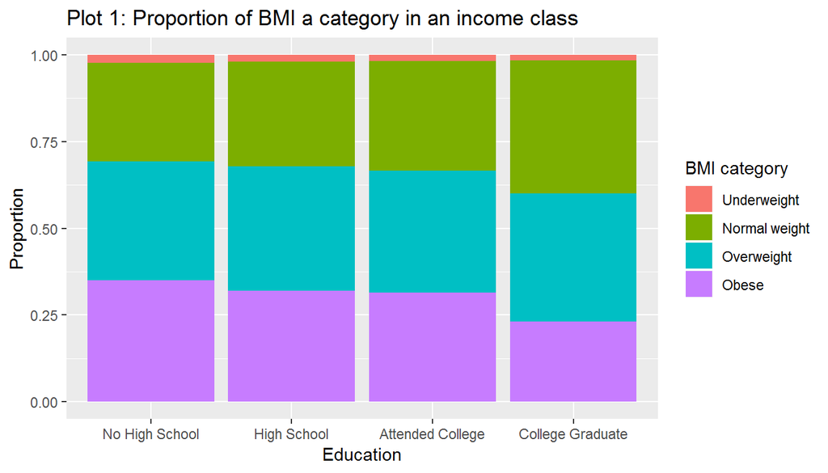

```r
#Plot 2: Proportion of each BMI category for each of the following educational qualification.

ggplot(aes(x=X_educag, fill=X_bmi5cat), data=EduBMI)+
      scale_x_discrete(name = "Education",
      labels = c("Did not graduate high school" = "No High School",
                "Graduated high school" = "High School",
                "Attended college or technical school" = "Attended College",
                "Graduated from college or technical school" = "College Graduate")) +
geom_bar(position = "fill") +
ggtitle("Plot 1: Proportion of BMI a category in an income class")+
scale_fill_discrete(name="BMI category")+
xlab("Eduational Background")+
ylab("Proportion")
```

It is observed that the chances of a person being Obese is lesser for higher educational qualifications. eg: a person with an under graduate degree or technical education is less likely to Obese when compared to a person who is a high school graduate.

The proportion of people overweight is pretty much the same for all educational qua;ifications.

But the likelihood of a person being normal weight increases as we go from left to right in the plot.

The chances of person being under weight becomes lesser with higher educational qualification, but the decrease is very gradual.

```r
table(IncomeBMI$X_bmi5cat,IncomeBMI$income2)
```

```
##
##                 Less than $10,000 Less than $15,000 Less than $20,000
##   Underweight                 735               654               765
##   Normal weight              7542              7685             10273
##   Overweight                 7122              8113             11014
##   Obese                      8564              9069             11117
##
##                 Less than $25,000 Less than $35,000 Less than $50,000
##   Underweight                 802               814               804
##   Normal weight             12470             14828             18397
##   Overweight                13846             16766             22142
##   Obese                     12767             14444             17957
##
##                 Less than $75,000 $75,000 or more
##   Underweight                 727            1333
##   Normal weight             19878           40461
##   Overweight                24006           43076
##   Obese                     18337           27289
```

```r
table(EduBMI$X_bmi5cat,EduBMI$X_educag)
```

```
##
##                 Did not graduate high school Graduated high school
##   Underweight                            928                  2577
##   Normal weight                        11055                 40934
##   Overweight                           13289                 48626
##   Obese                                13631                 43367
##
##                 Attended college or technical school
##   Underweight                                   2242
##   Normal weight                                40356
##   Overweight                                   44763
##   Obese                                        40093
##
##                 Graduated from college or technical school
##   Underweight                                         2501
##   Normal weight                                      62212
##   Overweight                                         60064
##   Obese                                              37517
```

*Summary Statistics:*

The interpretaion form the summary statistics is the same as the above plots, but care must be taken because the plots deal with proportions in a educational qualification but the table gives raw numbers.

**Research quesion 3:**

Variables Used:

sleptim1 : Sleep time X_rfhype5 : Indicator of whether the person suffers from hypertension or not. sex X_rfbing5 : Whether the person binge drinks alcohol

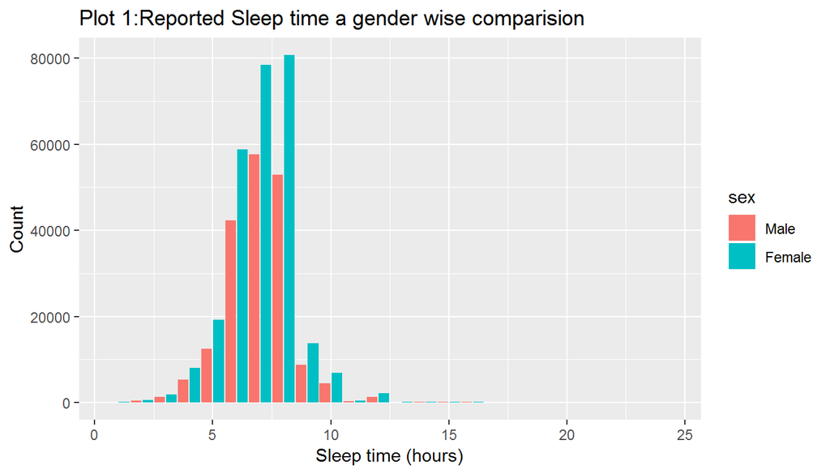

```r
#Variable defined for this plot

Q3 <- brfss2013
Q3 <- Q3[!is.na(brfss2013$sleptim1),]
Q3 <- Q3[!is.na(Q3$X_rfhype5),]
Q3 <- Q3[!is.na(Q3$sex),]
Q3 <- Q3[!is.na(Q3$X_rfbing5),]

#Plotting the sleep time and then comparing it gender wise

ggplot(data=Q3,aes(x=sleptim1,fill=sex))+
geom_histogram(binwidth = 1,position = position_dodge2())+
ggtitle("Plot 1:Reported Sleep time a gender wise comparision")+
xlab("Sleep time (hours)")+
ylab("Count")
```

```r
#Summary of sleeping time gender wise

Q3 %>% group_by(sex) %>% summarize(Avg_Sleep=mean(sleptim1),Std_Sleep=sd(sleptim1),Q2_Sleep=median(sleptim1),Observations=n())
```

```
## # A tibble: 2 x 5
##   sex    Avg_Sleep Std_Sleep Q2_Sleep Observations
##   <fct>      <dbl>     <dbl>    <dbl>        <int>
## 1 Male        7.03      1.44        7       187950
## 2 Female      7.06      1.47        7       272523
```

The distribution of the sleep time is symmetric for both genders and there doesn’t seem any difference in the distribution of the sleep hours.

For both genders the peak (median) is around the same time and both increase and decrease at together almost all time.

*Summary Statistics:*

The average sleep time for both male and female is approximately the same around 7 hours. The standard deviations of sleep times are also close. The mean and the median are equal in both of the above cases (7 hours).

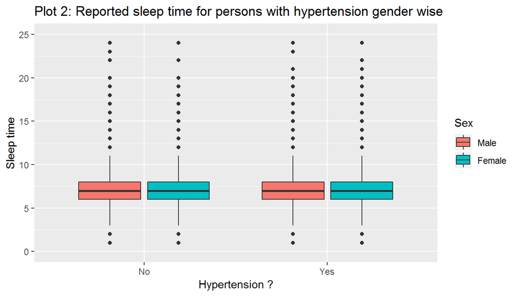

```r
#Plotting the sleep time of a person on whether s/he is having hypertension

ggplot(aes(x=X_rfhype5, y=sleptim1,fill=sex), data=Q3)+
     geom_boxplot() +
     ggtitle("Plot 2: Reported sleep time for persons with hypertension gender wise")+
     scale_fill_discrete(name="Sex")+
     xlab("Hypertension ?")+
     ylab("Sleep time")+
     ylim(0,25)
```

```r
#Summarizing the above plot

Q3 %>% group_by(Hypertension=X_rfhype5,Gender=sex) %>% summarise(Avg_Sleep=mean(sleptim1),Std_Sleep=sd(sleptim1),                                                          Q2_Sleep=median(sleptim1),Observations=n())
```

```
## # A tibble: 4 x 6
## # Groups:   Hypertension [2]
##   Hypertension Gender Avg_Sleep Std_Sleep Q2_Sleep Observations
##   <fct>        <fct>      <dbl>     <dbl>    <dbl>        <int>
## 1 No           Male        7.01      1.35        7       110143
## 2 No           Female      7.07      1.38        7       164009
## 3 Yes          Male        7.06      1.54        7        77807
## 4 Yes          Female      7.06      1.61        7       108514
```

The plot shows that the median sleep hours are the same in all the four cases that are studied. The inter quartile range is equal in all the cases. The plot doesnt indcate any significant difference in sleep time.

*Summary Statistics:*

The standard deviation is higher for people with hypertension indicating that they might actually sleep more or less. i.e the values are more extreme.

The median is same 7 hours.

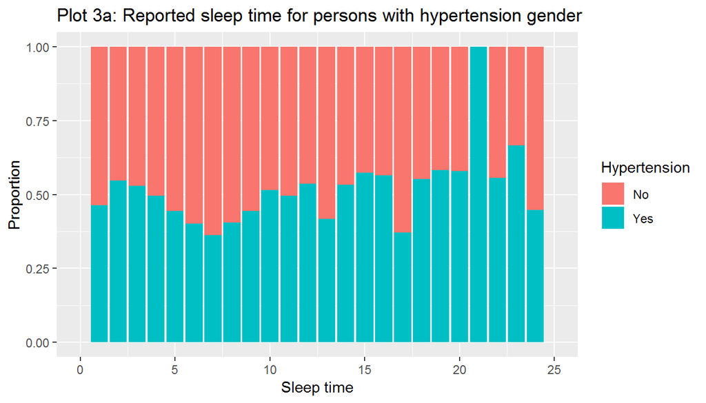

```r
#The plot above is not totally effective in helping up visualuze the sleeping trends thus we make a second attempt.

ggplot(aes(fill=X_rfhype5, x=sleptim1), data=Q3)+
     geom_bar(position = "fill") +
     ggtitle("Plot 3a: Reported sleep time for persons with hypertension gender")+
     scale_fill_discrete(name="Hypertension")+
     xlab("Sleep time")+
     ylab("Proportion")+
     xlim(0,25)
```

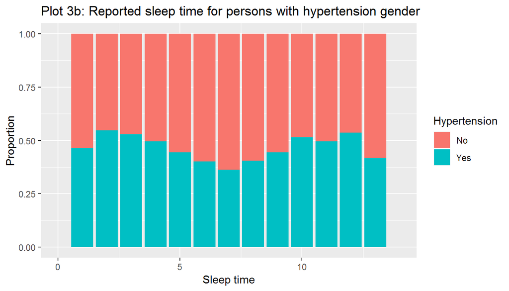

```r
#Perhaps we can take a better look at the data this way by excluding all the sleep entries that are greater than 14, coz a number greater than that is unreliable and unresonable.

ggplot(aes(fill=X_rfhype5, x=sleptim1), data=Q3)+
     geom_bar(position = "fill") +
     ggtitle("Plot 3b: Reported sleep time for persons with hypertension gender")+
     scale_fill_discrete(name="Hypertension")+
     xlab("Sleep time")+
     ylab("Proportion")+
     xlim(0,14)
```

```r
#Summarizing the above study

Q3 %>% group_by(Hypertension=X_rfhype5) %>% summarize(Avg_Sleep=mean(sleptim1),Std_Sleep=sd(sleptim1),                                            Q2=median(sleptim1),number_of_persons=n())
```

```
## # A tibble: 2 x 5
##   Hypertension Avg_Sleep Std_Sleep    Q2 number_of_persons
##   <fct>            <dbl>     <dbl> <dbl>             <int>
## 1 No                7.04      1.37     7            274152
## 2 Yes               7.06      1.58     7            186321
```

```r
#Plot checking for assocaition between a person bing drinking and s/he having hypertension
```

3 (a):The trend here appears to be not so clear. Thus we could plot it again removing the unresonable values. i.e. above 14 hours.

*Summary Statistics:*

The standard deviation of sleep time for people with and without hypertension seem to uphold the observations made in the the plot.

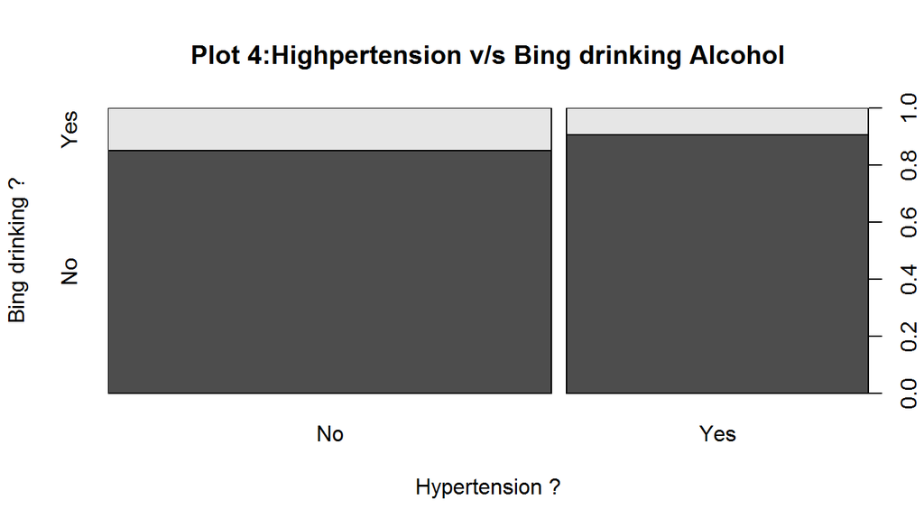

```r
plot(Q3$X_rfhype5,Q3$X_rfbing5,xlab="Hypertension ?",ylab="Bing drinking ?",main="Plot 4:Highpertension v/s Bing drinking Alcohol")
```

```r
#Tabluating the above plot numerically

table(Hypertension=Q3$X_rfhype5,Bing_Drinking=Q3$X_rfbing5)
```

```
##             Bing_Drinking
## Hypertension     No    Yes
##          No  233341  40811
##          Yes 168758  17563
```

This plot clearly shows that there is a significant difference in the likelihood of a person bing drinking alcohol given that s/he is suffering from hypertension.

*Summary Statistics:*

The table numberically presents the results of the above study.